# The Politics of Corruption

Lecture 4: Corruption as an Equilibrium: Norms and Collective Action

Bogdan G. Popescu

bgpopescu@tec.mx

Tecnológico de Monterrey

## The ask

- Twenty dollars now, or a week she cannot afford to lose.
- The fee is posted on the wall. The twenty dollars is for skipping the wait.
- Nothing here is hidden. She knows exactly what is being sold.

And she is not alone in this queue. Behind her stand a shopkeeper, a cook and a driver, all with the same paperwork and the same officer.

**Three answers, one at a time. Listen for the one who disagrees.**

## Everyone agrees

- Sofia, the cook, and the driver all say the same thing.
- Not one of them is defending bribery.
- Put them in a survey and you would record three clean answers.

**The norm is not missing, then. Is having it enough?**

## An hour later, at the window

The line has not gone away. Neither has the officer.

## What Sofia is watching

- She has not moved. The others have.
- Nothing she believes about bribery has changed.
- What changed is what she now expects the queue to do.

**If everyone else pays, what exactly does her refusal buy?**

## What just happened?

- Four people who all call bribery wrong. Four people who pay.
- No one was argued out of their principles.
- Each acted on what they expected the others to do.

Everyone kept the rule in their head. Nobody kept it at the window.

**Is this hypocrisy — or is it a trap?**

## The Puzzle — and Today’s Route

Four people who all said bribery was wrong. Four people who paid. **Not one of them changed their mind.**

So the puzzle is not why people *approve* of corruption. Almost nobody does. It is why disapproval so often fails to stop it.

**Four questions:**

1. What makes a rule bind at all — and what went missing here?
2. Sofia is invented. Does any of this happen **for real**?
3. One dishonest official, or a trap everyone is caught in?
4. If it is a trap, what can a reform actually do?

# I. Why Do People Join In?

What a norm actually is, why it can stop binding, and whether it travels with people.

## Two questions you ask without noticing

Almost everyone agrees bribery is wrong. So the **rule** is not what is missing.

Then what makes a rule actually bind? Before following one, you quietly check two things:

- **Does anyone actually do this?**
- **Would people mind if I didn’t?**

**Empirical expectation** — what I think others *really do*.

**Normative expectation** — what I think others *expect of me*.

A rule grips people only when **both** answers are yes. Bicchieri calls that a **conditional preference**: I want to follow the rule *provided* others are.

Bicchieri (2006), *The Grammar of Society*, ch. 1.

## Four borders Sofia could have walked into

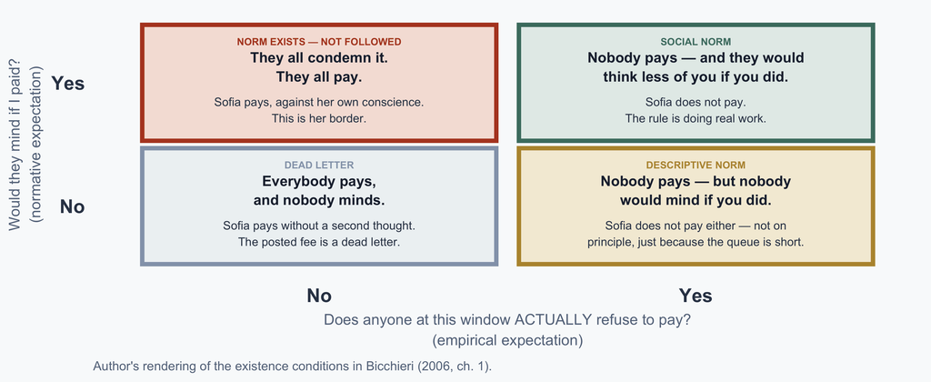

Sofia is in the top-left box. One yes out of two — the rule is still in everybody’s head, it just no longer describes the queue. Both answers have to be yes.

## Why three people were enough

- Each person who pays makes paying more sensible for the next one in line.
- So small changes bounce off: for years, the norm does not budge.
- Then enough of them accumulate, the **tipping point** is passed, and the old norm goes all at once.

**Tipping point** — the moment when enough people have switched that switching becomes the sensible thing for everyone else too.

Burke & Young (2011), “Social Norms,” *Handbook of Social Economics*, ch. 8.

## Flat, then a cliff, then flat again

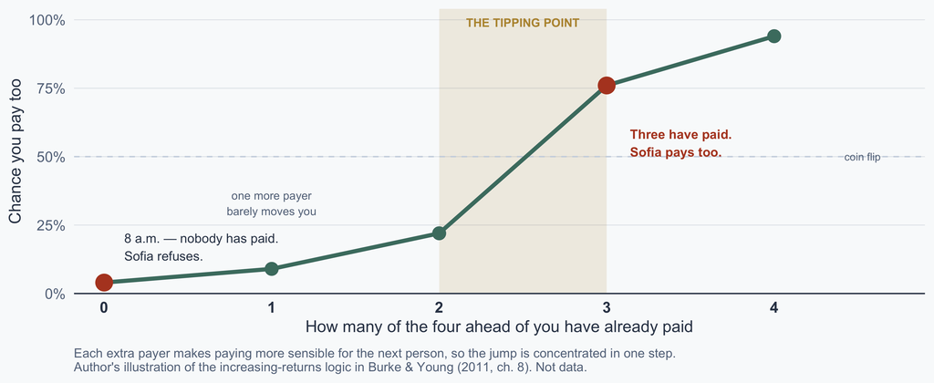

Sofia did not need everyone to pay. She needed **enough**.

## So why don’t people just copy the locals?

- Move somewhere honest and you would expect to pick up honest habits. Often people don’t.
- Simpser studies people **born and raised in one country**, under the same laws and the same police, whose **parents** came from different ones.
- Their attitudes to bribery still track the **parents’** country, a full generation later.
- Staying close to family and community is what makes fitting in costly.

An attitude can outlive the place that produced it.

Simpser (2020), *The Culture of Corruption across Generations*. The cost-of-fitting-in argument is Lazear (1999).

## Same country, different parents

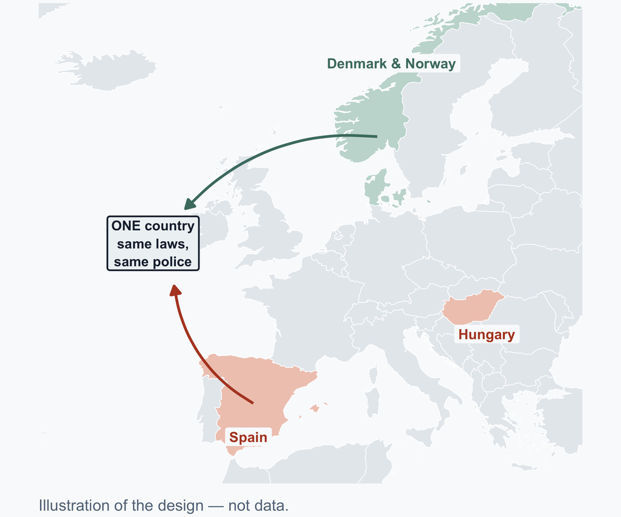

**The actual question** (European Social Survey, 2004):

*“How wrong, if at all, do you consider the following ways of behaving to be — a public official asking someone for a favour or bribe in return for their services?”*

Answers: not wrong at all · a bit wrong · wrong · **seriously wrong**

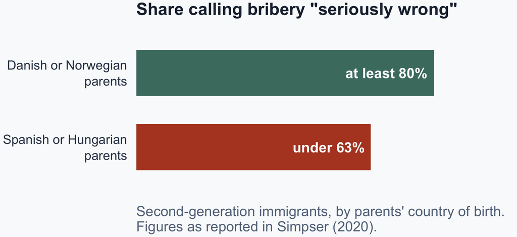

## What this does and does not settle

- It does **not** make culture destiny. Simpser finds attitudes shifting across generations too.
- They shift slowly where bribery is tolerated, faster where it is punished.
- And it cannot explain Sofia: nothing about her upbringing changed between morning and afternoon.

**Two forces, then: what you bring with you, and what the queue in front of you is doing today.**

# II. Does It Show Up in Behaviour?

## How Can We Separate Rules from Norms?

- People from corrupt countries also face weaker enforcement at home
- So comparing countries cannot tell us which one matters
- We would need people from many countries under **identical** rules
- And a moment when the rules change but the people do not

Fisman and Miguel (2007) found a place where both were true.

## Diplomatic Immunity as a Natural Test

[figure not shown]

- Around 1,700 UN diplomats from 149 countries
- Nearly all missions sit within a mile of UN headquarters
- Same city, same streets, same parking signs
- Before Nov 2002, an unpaid ticket cost them **nothing**
- So how they parked revealed what they had brought with them

Design from Fisman & Miguel (2007).

## Same city, same streets, same signs

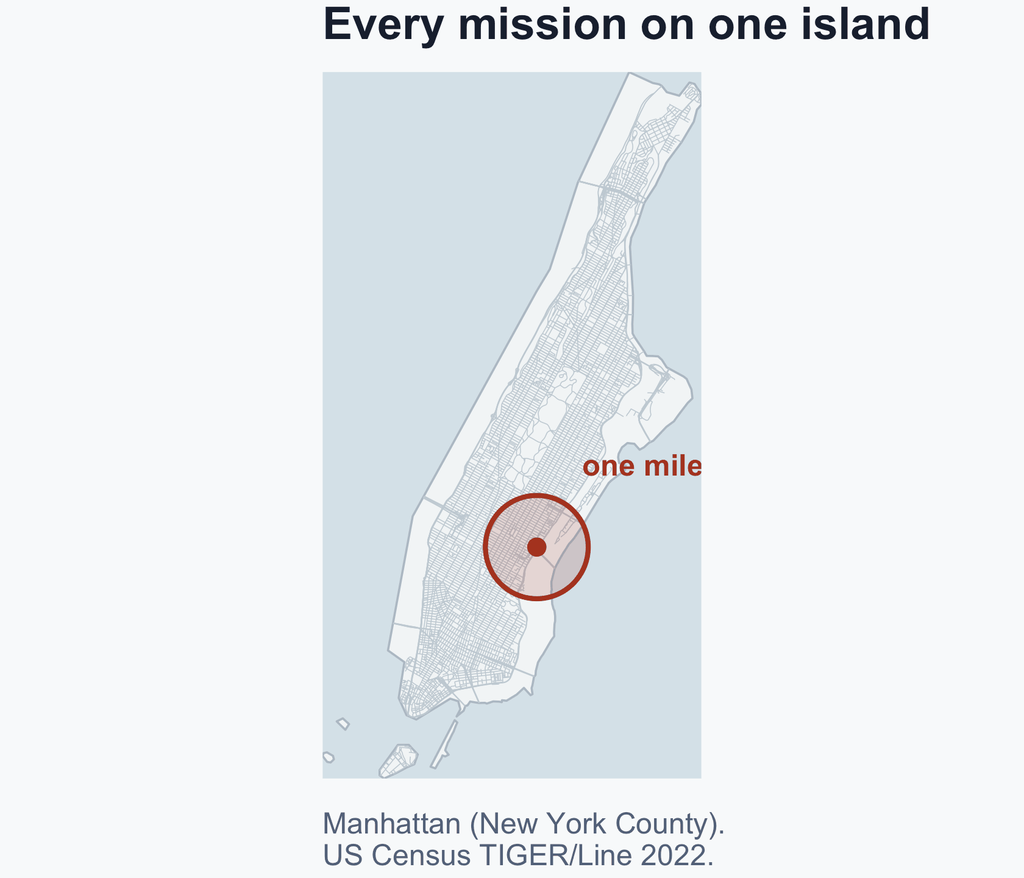

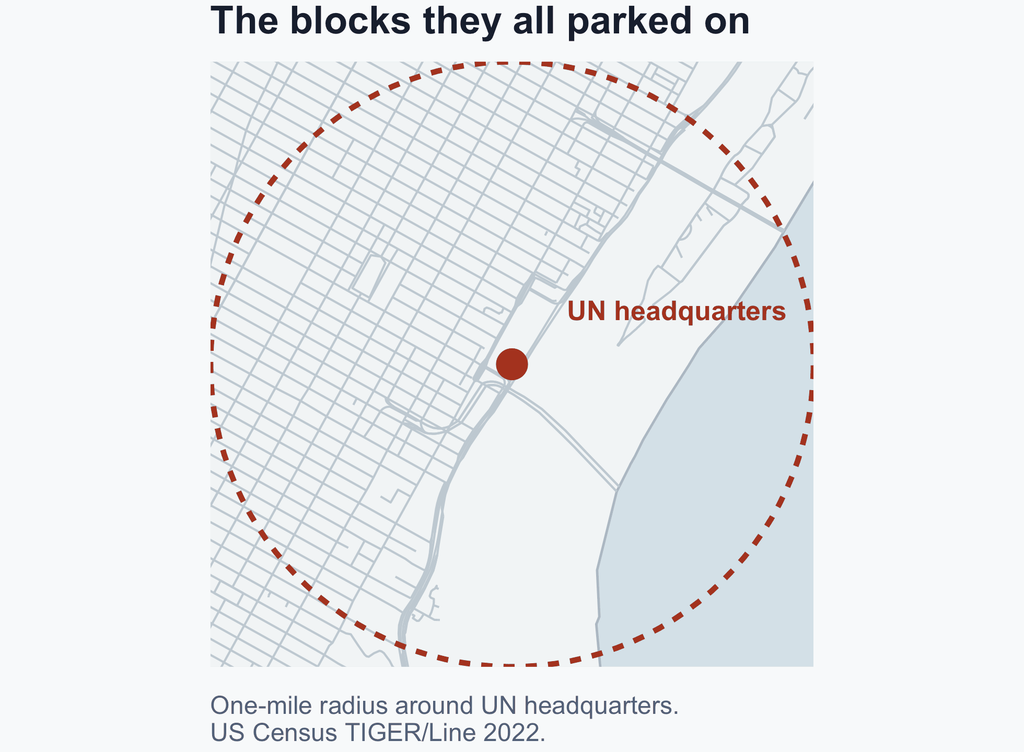

Same streets, same signs, same wardens. Whatever differed, it was not the rules.

## Three blocks by the East River

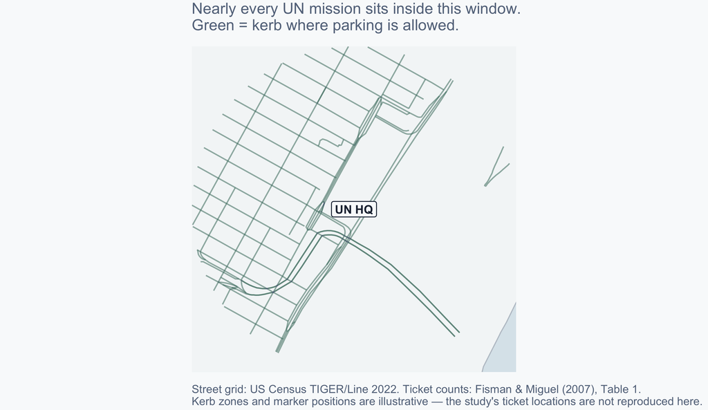

## Where you may not stand

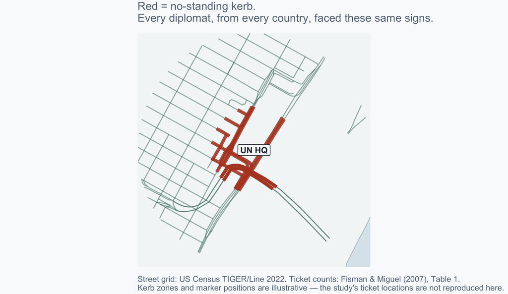

## Germany’s diplomats: one ticket all year

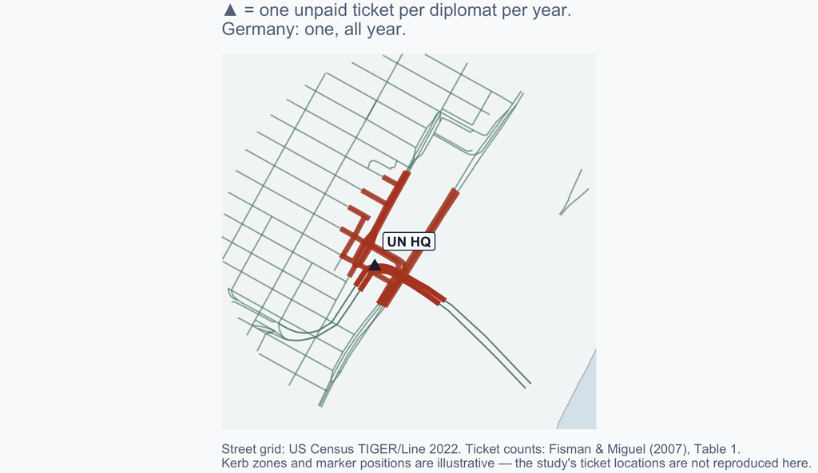

## Egypt’s diplomats: 141 each

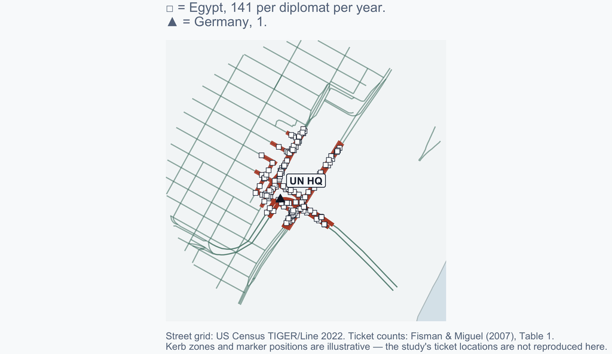

The signs, the wardens and the penalty were the same for everyone here. Only the drivers differed.

## 150,000 tickets. $18 million. Nothing collected.

Not one of them carried a penalty. Whatever governed how these diplomats parked, it was **not** the law.

Fisman & Miguel (2007). Around 1,700 diplomats from 149 countries.

## When Nobody Was Watching

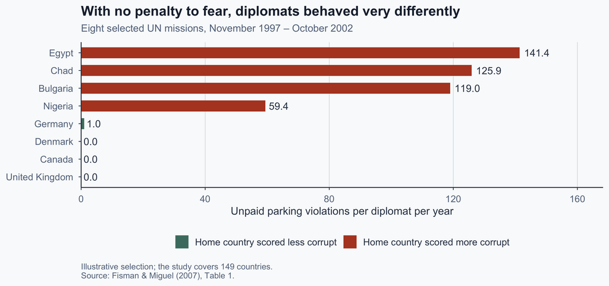

## What the Comparison Can and Cannot Show

- The pattern is real, but it is not perfect
- Kuwait, the very worst violator, scored as relatively clean
- Small missions own few cars, so they park badly less often
- The researchers therefore compared countries **adjusting for mission size**

On that comparison, moving from Nigeria’s score to Norway’s implies roughly an **80% drop** in violations.

## Then Enforcement Arrived

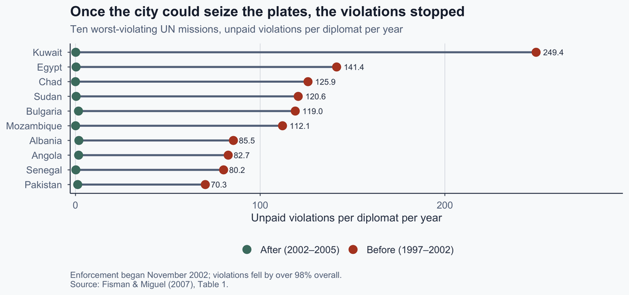

## What the Diplomats Teach Us

- For five years there was **no penalty at all**. All that was left was what each diplomat brought with them.
- And that differed hugely: **141 unpaid tickets a year, against 1**.
- Then the plates started coming off. Violations fell **98%** in months.

Both mattered, at different moments: what they brought with them while nothing was enforced, and the plates once something was.

**Still open:** something travels with people. But *what*? A belief about others, a habit, or a conviction? That is the next study.

## Does Believing It Is Spreading Make People Bribe?

- **The question:** does hearing that corruption is rising make people join in?
- **The test:** 4,200 people interviewed across Costa Rica’s main urban area
- Some, chosen at random, were shown a flyer reporting rising corruption
- Everyone was then asked whether they would bribe a traffic officer

Because the flyer was assigned by chance, any difference is caused by the information.

Corbacho, Gingerich, Oliveros & Ruiz-Vega (2016).

## What the flyer actually said

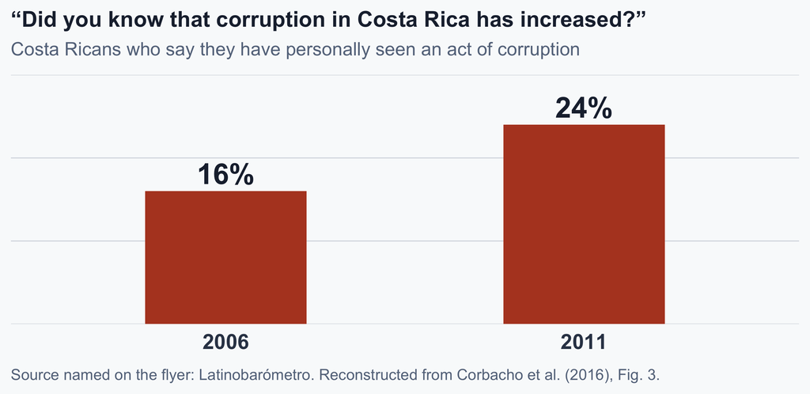

- A third of people saw this. A third saw nothing.
- The last third saw a **placebo**: same design, equally bad news, but about slow courts.
- The placebo changed nothing. So it is the *message*, not the bad mood, that moved people.

## Believing Corruption Is Rising Makes People Willing to Bribe

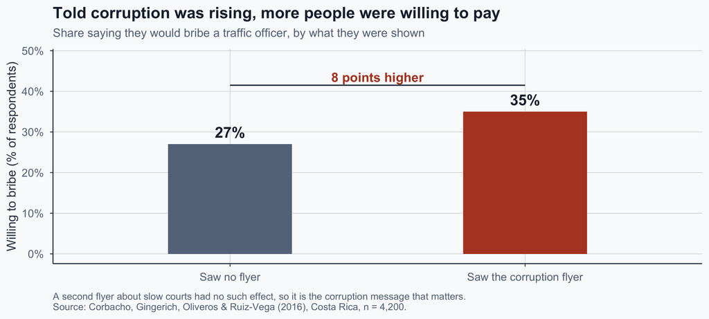

## What the Two Studies Add Up To

- Diplomats acted on norms brought from home, where nothing was enforced
- Costa Ricans became more **willing** to bribe once told corruption was rising
- The two studies do different jobs — one tracks behaviour, the other isolates belief
- And expectations can make themselves come true

**Mind the gap:** Corbacho measures *stated willingness*, not observed bribery. Fisman & Miguel measures real behaviour but cannot tell us *which* learned disposition is doing the work.

**Next:** if expectations are the problem, what should reform actually target?

# III. Principal–agent vs. Collective Action Problem

## The container clears. Now she needs a permit.

- Sofia paid the $20. The barrier lifted; the cargo is through.
- To move it out of the yard she needs a permit from the Northland Permit Office.
- A different building, a different queue, the same question waiting for her.

**Two versions of that office. Watch what changes.**

## Story A — one window asks

- Four windows. Three of them process her neighbours without comment.
- At window 2, the clerk names a figure: **twenty dollars** — the same price as the barrier.
- Behind the glass at the back sits a supervisor who wants permits issued properly.
- He simply cannot see what happens at the counter.

**Ask yourself:** what exactly is the problem here — and who could fix it?

## Story B — every window asks

- Same office, same queue, same Sofia. This time **every** clerk names a figure.
- The supervisor has left his desk. He is at the counter, taking his share.
- Reporting it would mean reporting to the man collecting the cut.
- Refusing does not get her a clean permit. It gets her no permit.

## Two Names for Two Problems

The same corrupt payment, two very different situations. Author’s summary of Persson, Rothstein & Teorell (2013).

|  | **Story A** | **Story B** |
| --- | --- | --- |
| What goes wrong | One person hides bad behaviour | Everyone expects everyone else to cheat |
| Who can fix it | The boss, by watching more closely | Nobody acting alone |
| Honest people are | The normal case | Punished as fools |
| Political scientists call it | A **principal–agent** problem | A **collective-action** problem |

## Principal–agent problem

Someone hands a job to someone else — and cannot watch them do it.

- **The principal** — the supervisor. Wants permits issued properly.
- **The agent** — the clerk. Wants the twenty dollars.
- They want **different things**, and only one of them is at the counter.
- The clerk knows what happened there. The supervisor does not.

That gap has a name: **information asymmetry**. It is what makes the betrayal possible.

**So the fix is obvious** — watch more closely, audit, raise the penalty. It works because *somebody at the top wants it fixed*.

Rose-Ackerman (1978); Klitgaard (1988), who summarises the diagnosis as *monopoly plus discretion minus accountability*. Framing follows Persson, Rothstein & Teorell (2013).

## Collective-action problem

Everyone would be better off if nobody paid. Each person alone is still better off paying.

- **Nobody is exempt** — clerks, applicants and the supervisor are all following their own interest.
- What is sensible **for me** depends on what I expect **from you**.
- The more people expected to pay, the more sense paying makes.
- Past a point it flips: enough others pay, and joining in is simply what a sensible person does.

**And now there is no principal.** Principal–agent theory assumes somebody wants the rules enforced. Collective-action theory asks whether anybody does — including the supervisor, who is taking a share.

Persson, Rothstein & Teorell (2013), drawing on Ostrom (1998).

## Equilibrium

A situation nobody will step out of on their own — even when everybody would rather it were different.

- Sofia would prefer an office where nobody pays.
- So would the applicant next to her. So, most likely, would the clerks.
- But given what everyone else is doing, paying is still her best move.
- Refusing costs her the permit, and nobody else notices.

Add up everyone’s best move and you get a situation nobody chose and nobody can leave on their own.

**So “just stop paying” is not advice.** It asks one person to carry the whole cost of a change that needs everybody.

The collective-action reading of corruption: Persson, Rothstein & Teorell (2013).

# IV. What Does That Mean for Reform?

If corruption is an equilibrium rather than hidden misconduct, what follows for policy?

## Why Standard Reforms Can Fail

> You report to someone who has already been bribed. And then it ends there.
- **The usual diagnosis:** corrupt agents evade monitoring.
- **The usual remedy:** more monitoring, stronger agencies, higher penalties.
- But audits need honest auditors; reporting needs someone willing to act; punishment needs prosecutors willing to prosecute.
- **The problem:** if the supervisor is taking a share too, who enforces the reform?

Interviews with 60+ Kenyan and Ugandan officials, journalists and NGO staff (Persson, Rothstein & Teorell 2013).

## Kenya and Uganda Did Everything the Playbook Says

- **Kenya**: an Anti-Corruption and Economic Crimes Act, a Public Officers Ethics Act, and the UN Convention against Corruption.
- **Uganda**: an Inspectorate General of Government as lead anticorruption agency, plus an Auditor General and a Directorate of Ethics and Integrity.
- Global Integrity rated both legal frameworks “very strong” — **100 out of 100**.

Then it measured how much of it was actually being applied.

The gap between law and practice: **“large” in Kenya, “huge” in Uganda.** Since 1998, corruption in neither country has been anything but rampant.

Watching more closely is not wrong. It quietly assumes the very thing that is missing — somebody who wants to watch.

Global Integrity (2008), reported in Persson, Rothstein & Teorell (2013).

## What Would Have to Change?

- **Behaviour** — people must actually meet different rules and different consequences.
- **Expectations** — people must have reason to think everybody else has met them too.
- Suppose the police really have been cleaned up.
- You believe it.
- But you think everyone else still expects to pay.
- So you pay anyway, and so does everyone reasoning the same way.

I have to believe the rules changed, and I have to think you believe it too. The second one is the hard part.

## What Might Make a Reform Credible?

- **Visible** — people can see that conduct has actually changed, not just that a statute passed.
- **Credible** — enforcement really happens, including against insiders.
- **Coordinated** — reporting, prosecution and staffing move together, rather than one rule changing on paper.

A prosecuted minister works mostly as **information**: it tells everyone that everyone else has now seen the same thing.

**Careful.** Collective-action theory *predicts* these three should matter. The studies in this lecture do not establish the best reform package.

## What Do We Actually Know?

Where the findings stop and the prescription begins.

| The evidence supports | The theory infers from it |
| --- | --- |
| Norms travel with people, even where nothing is enforced | Corruption can settle into a self-holding equilibrium |
| Telling people corruption is rising raises their **willingness** to bribe | Reform must shift what people expect of one another |
| Credible enforcement changed diplomats’ behaviour within months | Enforcement works through belief, not penalties alone |
| *(no direct evidence here)* | Coordinated overhaul beats isolated fixes |

That last row is what Session 2 would call **plausible but not established** — and it is the row the whole reform argument rests on. Press it.

## Exercise — You Take Over the Permit Office

Every clerk at the Northland Permit Office takes twenty dollars. Your predecessor took a share. Three months, no new budget.

**Choose two:**

1. Fire the two worst clerks
2. Put a camera at every window
3. Raise the penalty for taking a payment
4. Publish each week how many permits were issued without payment
5. Publicly prosecute your predecessor

**For each one, answer:**

- **What happens the next morning?** Does a clerk actually stop asking for the twenty dollars — and why?
- **What would make it fail?** Who could ignore it, sabotage it, or fake it?

## Takeaways

- **Everyone already agrees bribery is wrong.** That was never the missing piece. What failed at Sofia’s window was expecting anyone else to refuse.
- **Both the person and the room matter.** Diplomats kept their home habits once nothing was enforced; Costa Ricans told corruption was rising became readier to pay.
- **One corrupt clerk and a captured office look identical from outside.** The first needs a watchful boss. The second has nobody left to watch.
- **So the diagnosis comes before the cure.** Cameras and penalties fix the first office and bounce off the second.
- **And we know the trap is real better than we know the way out.**

Corruption survives not because everyone wants it, but because everyone may be waiting for everyone else to stop first.

## References

Corbacho, A., Gingerich, D. W., Oliveros, V., & Ruiz-Vega, M. (2016). Corruption as a self-fulfilling prophecy: Evidence from a survey experiment in Costa Rica. *American Journal of Political Science, 60*(4), 1077–1092. https://doi.org/10.1111/ajps.12244

Fisman, R., & Miguel, E. (2007). Corruption, norms, and legal enforcement: Evidence from diplomatic parking tickets. *Journal of Political Economy, 115*(6), 1020–1048. https://doi.org/10.1086/527495

Global Integrity. (2008). *Global Integrity report 2008*. Global Integrity.

Kaufmann, D., Kraay, A., & Mastruzzi, M. (2005). *Governance matters IV: Governance indicators for 1996–2004* (Policy Research Working Paper No. 3630). World Bank.

Klitgaard, R. (1988). *Controlling corruption*. University of California Press.

## References (continued)

Persson, A., Rothstein, B., & Teorell, J. (2013). Why anticorruption reforms fail—Systemic corruption as a collective action problem. *Governance, 26*(3), 449–471. https://doi.org/10.1111/j.1468-0491.2012.01604.x

Rose-Ackerman, S. (1978). *Corruption: A study in political economy*. Academic Press.

Rothstein, B. (2011). *The quality of government: Corruption, social trust, and inequality in international perspective*. University of Chicago Press.